# ColtExpress Heuristic Tuning

The results in the tabs below show the Colt Express heuristic parameters optimised against each of three opponents:

- Random (RND)
- One Step Lookahead (OSLA) that optimises the score immediately after the next move (using the default heuristic)
- An MCTS agent with 20ms computational budget per decision (Rollout and Tree depth of 10, K = 1.41, using classic Open-Loop UCB with SelfOnly search), also using the default heuristic.

The agent MCTS parameters are fixed at K=1, UCB, SelfOnly, rollout=30, maxTreeDepth=30 so that we are just optimising over the heuristic parameters. The default setting for the Colt Express Heuristic has:

| maxLoot | LOOT | BULLET_CARDS | BULLETS_PLAYER | BULLETS_ENEMY |
| --- | --- | --- | --- | --- |
| 5000 | 0.5 | -0.3 | -0.2 | 0.1 |

The conclusions from the NTBEA runs are:

- maxLoot = 1000 is clearly preferred in every single NTBEA run (all opponents and all player counts)!
- The LOOT factor also should be higher than 0.5
- The three BULLET factors are less important, but BULLETS_PLAYER should be negative. (CARDS is important with 2P, but not elsewhere)
- MultiNTBEA again gives very flat distributions and no useful results. It doesn’t even highlight the importance of maxLoot!
- With optimised heuristics, MCTS win rates with 4P against MCTS using the original heuristic goes from 31% to 91% - a rather drastic improvement.

The conclusion from all this was not to directly use the heuristic, but add a new one, `ScoreHeuristic`, which takes the raw game score and uses this directly as a heuristic. In the case of ColtExpress the final score comprises two elements:

1. The total value of loot (covered by LOOT and maxLoot)
2. A bonus awarded to the player(s) who have got rid of more of their own bullets (by shooting other players successfully; covered by BULLETS_PLAYER.

`ScoreHeuristic` calculates the sum of these two (the second is weighted linearly from 0.0 at the start to 1.0 in the last round of the game to account for its lack of reliability as a guide in the early game when only a few bullets have been fired). Actually winning the game gives a 50% bonus; losing gives a 50% malus.

…results of that in the next set of experiments.

## Heuristic

### RND

Mean Win rate over all NTBEA runs

| Type | 2P | 3P | 4P |
| --- | --- | --- | --- |
| Win Rate | 99% | 96% | 92% |

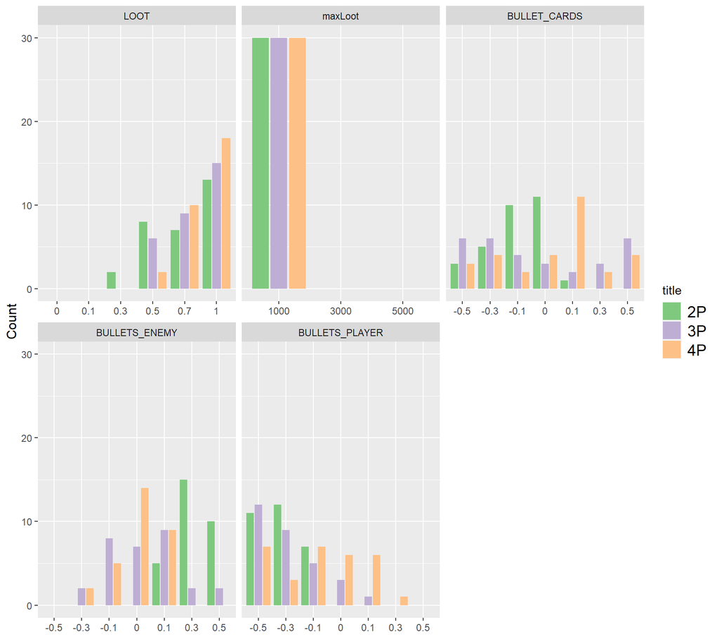

Significant p-Values on Chi-squared test for homogeneity - only extreme values highlighted

| Parameter | 2P | 3P | 4P | All |
| --- | --- | --- | --- | --- |
| LOOT | p < 0.001 | p < 0.001 | p < 0.001 | p < 0.001 |
| maxLoot | p < 0.001 | p < 0.001 | p < 0.001 | p < 0.001 |
| BULLET_CARDS | p < 0.001 |  |  | p < 0.001 |
| BULLETS_ENEMY | p < 0.001 |  | p < 0.001 | p < 0.001 |
| BULLETS_PLAYER | p < 0.001 | p < 0.001 |  | p < 0.001 |

### OSLA

Mean Win rate over all NTBEA runs

| Type | 2P | 3P | 4P |
| --- | --- | --- | --- |
| Win Rate | 99% | 96% | 91% |

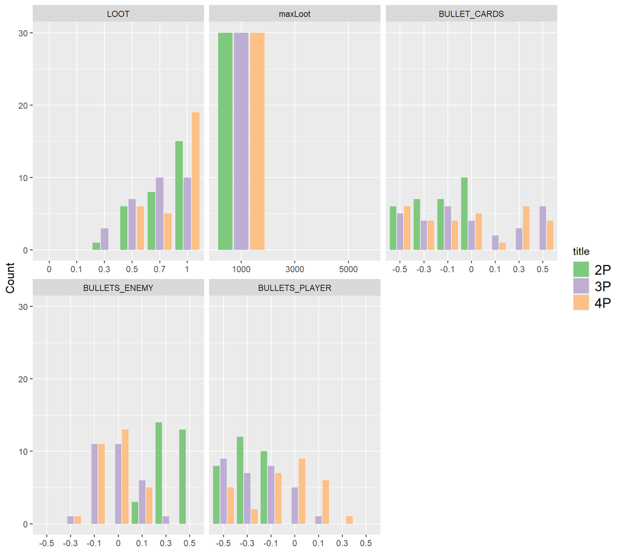

Significant p-Values on Chi-squared test for homogeneity - only extreme values highlighted

| Parameter | 2P | 3P | 4P | All |
| --- | --- | --- | --- | --- |
| LOOT | p < 0.001 | p < 0.001 | p < 0.001 | p < 0.001 |
| maxLoot | p < 0.001 | p < 0.001 | p < 0.001 | p < 0.001 |
| BULLET_CARDS | p < 0.001 |  |  |  |
| BULLETS_ENEMY | p < 0.001 | p < 0.001 | p < 0.001 | p < 0.001 |
| BULLETS_PLAYER | p < 0.001 |  |  | p < 0.001 |

### MCTS

Mean Win rate over all NTBEA runs

| Type | 2P | 3P | 4P |
| --- | --- | --- | --- |
| Win Rate | 96% | 93% | 91% |

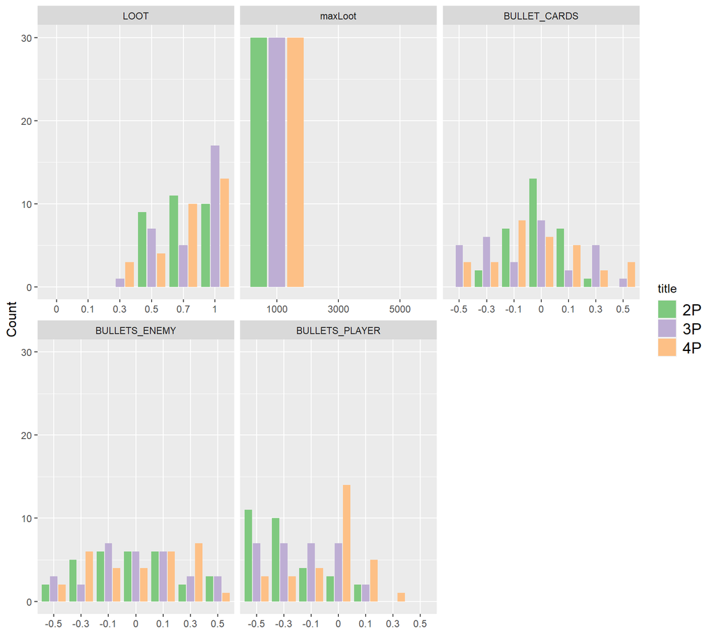

Significant p-Values on Chi-squared test for homogeneity - only extreme values highlighted

| Parameter | 2P | 3P | 4P | All |
| --- | --- | --- | --- | --- |
| LOOT | p < 0.001 | p < 0.001 | p < 0.001 | p < 0.001 |
| maxLoot | p < 0.001 | p < 0.001 | p < 0.001 | p < 0.001 |
| BULLET_CARDS | p < 0.001 |  |  | p < 0.001 |
| BULLETS_ENEMY |  |  |  |  |
| BULLETS_PLAYER | p < 0.001 |  | p < 0.001 | p < 0.001 |

### Multi

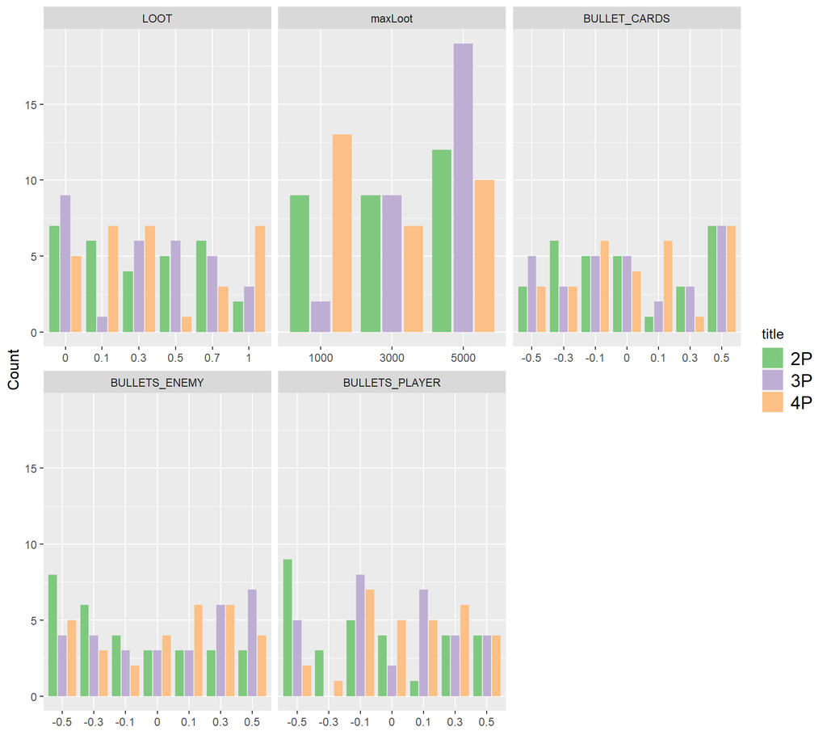

Significant p-Values on Chi-squared test for homogeneity - only extreme values highlighted

| Parameter | 2P | 3P | 4P | All |
| --- | --- | --- | --- | --- |
| LOOT |  |  |  |  |
| maxLoot |  | p < 0.001 |  |  |
| BULLET_CARDS |  |  |  |  |
| BULLETS_ENEMY |  |  |  |  |
| BULLETS_PLAYER |  |  |  |  |

### 2P

Mean Win rate over all NTBEA runs

| Type | MCTS | OSLA | RND |
| --- | --- | --- | --- |
| Win Rate | 96% | 99% | 99% |

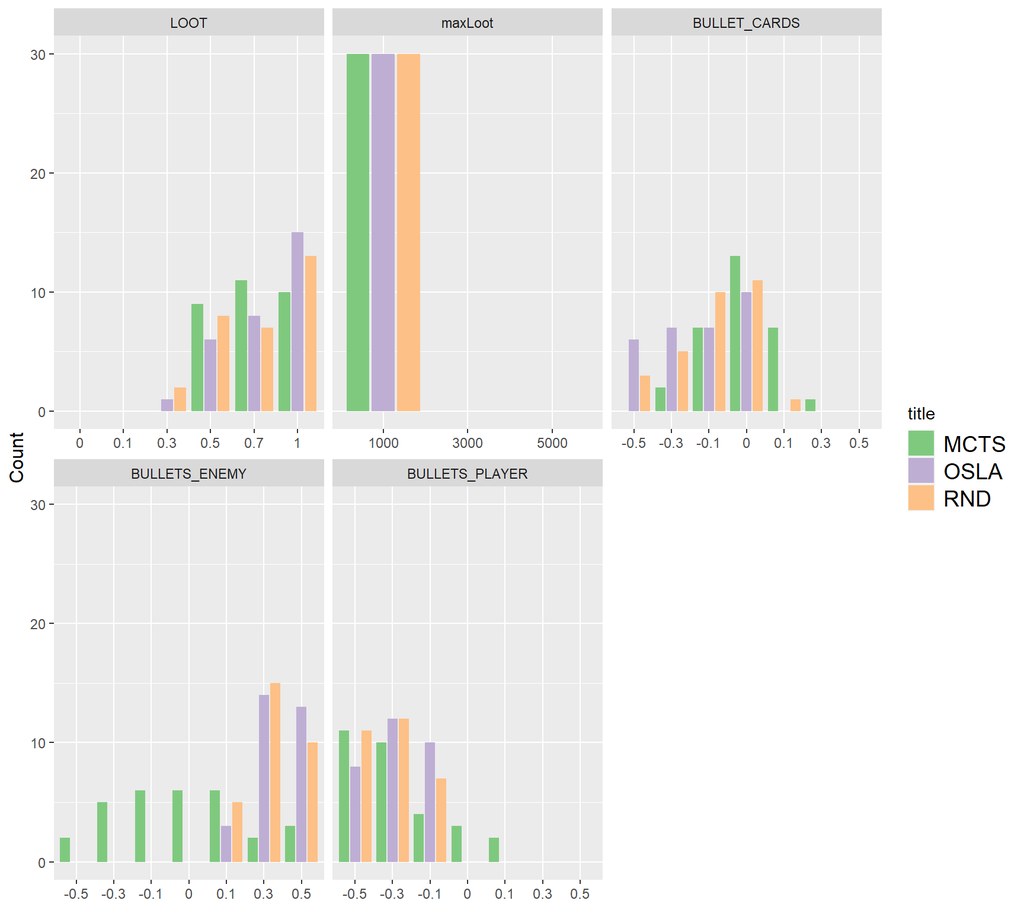

Significant p-Values on Chi-squared test for homogeneity - only extreme values highlighted

| Parameter | MCTS | OSLA | RND | All |
| --- | --- | --- | --- | --- |
| LOOT | p < 0.001 | p < 0.001 | p < 0.001 | p < 0.001 |
| maxLoot | p < 0.001 | p < 0.001 | p < 0.001 | p < 0.001 |
| BULLET_CARDS | p < 0.001 | p < 0.001 | p < 0.001 | p < 0.001 |
| BULLETS_ENEMY |  | p < 0.001 | p < 0.001 | p < 0.001 |
| BULLETS_PLAYER | p < 0.001 | p < 0.001 | p < 0.001 | p < 0.001 |

### 3P

Mean Win rate over all NTBEA runs

| Type | MCTS | OSLA | RND |
| --- | --- | --- | --- |
| Win Rate | 93% | 96% | 96% |

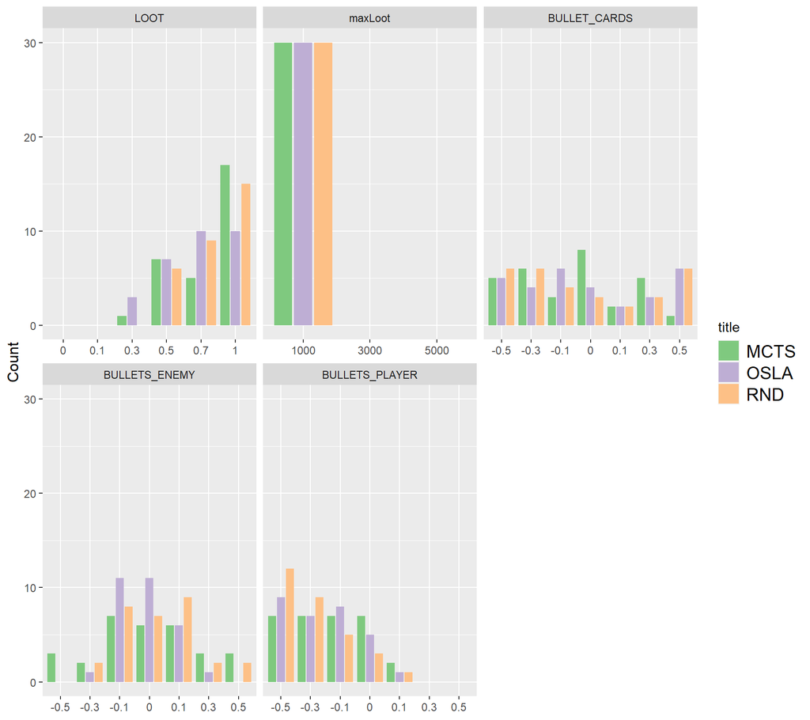

Significant p-Values on Chi-squared test for homogeneity - only extreme values highlighted

| Parameter | MCTS | OSLA | RND | All |
| --- | --- | --- | --- | --- |
| LOOT | p < 0.001 | p < 0.001 | p < 0.001 | p < 0.001 |
| maxLoot | p < 0.001 | p < 0.001 | p < 0.001 | p < 0.001 |
| BULLET_CARDS |  |  |  |  |
| BULLETS_ENEMY |  | p < 0.001 |  | p < 0.001 |
| BULLETS_PLAYER |  |  | p < 0.001 | p < 0.001 |

### 4P

Mean Win rate over all NTBEA runs

| Type | MCTS | OSLA | RND |
| --- | --- | --- | --- |
| Win Rate | 91% | 91% | 92% |

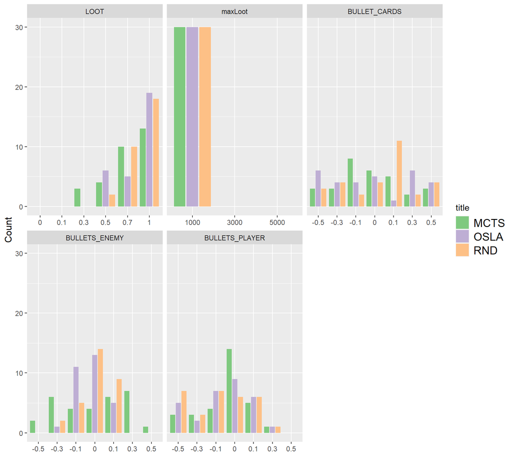

Significant p-Values on Chi-squared test for homogeneity - only extreme values highlighted

| Parameter | MCTS | OSLA | RND | All |
| --- | --- | --- | --- | --- |
| LOOT | p < 0.001 | p < 0.001 | p < 0.001 | p < 0.001 |
| maxLoot | p < 0.001 | p < 0.001 | p < 0.001 | p < 0.001 |
| BULLET_CARDS |  |  |  |  |
| BULLETS_ENEMY |  | p < 0.001 | p < 0.001 | p < 0.001 |
| BULLETS_PLAYER | p < 0.001 |  |  | p < 0.001 |

## Overall NTBEA recommendations

Final NTBEA recommendations

| title | WinRate | maxLoot | BULLET_CARDS | BULLETS_ENEMY | LOOT | BULLETS_PLAYER |
| --- | --- | --- | --- | --- | --- | --- |
| 2P RND | 99.2 +/- 0.6% | 1000 | 0.1 | 0.3 | 0.3 | -0.3 |
| 2P OSLA | 99.3 +/- 0.5% | 1000 | 0.0 | 0.5 | 0.5 | -0.3 |
| 2P MCTS | 98.1 +/- 0.9% | 1000 | 0.0 | 0.1 | 1.0 | -0.5 |
| 3P RND | 97.3 +/- 1.1% | 1000 | 0.1 | 0.1 | 1.0 | -0.5 |
| 3P OSLA | 97 +/- 1.1% | 1000 | -0.5 | 0.0 | 0.7 | -0.1 |
| 3P MCTS | 95.3 +/- 1.4% | 1000 | 0.0 | -0.5 | 0.5 | -0.3 |
| 4P RND | 93.1 +/- 1.7% | 1000 | -0.5 | 0.1 | 1.0 | -0.3 |
| 4P OSLA | 94.4 +/- 1.5% | 1000 | 0.3 | -0.1 | 1.0 | -0.5 |
| 4P MCTS | 93.3 +/- 1.7% | 1000 | 0.3 | 0.1 | 0.7 | 0.0 |